# Introduction to R

## Names

- You can give the elements of your vector names either directly or using the `names()` command.
- This is very useful for accessing elements (see next slide)

```r
avg_temp <- c(Maastricht = 14.2, Amsterdam = 13.4, Rotterdam = 13.7)
print(avg_temp) # names appear on top of elements
```

```
Maastricht  Amsterdam  Rotterdam
      14.2       13.4       13.7
```

```r
names(avg_temp) # returns names of elements
```

```
[1] "Maastricht" "Amsterdam"  "Rotterdam"
```

```r
# Alternatively, we can define data and names separately
temp <- c(14.2, 13.4, 13.7)
names(temp) <- cities # recall that we have defined "cities" earlier!
print(temp)
```

```
Maastricht  Amsterdam  Rotterdam
      14.2       13.4       13.7
```

## Accessing elements

- One can access the elements of a vector either by name or position.

```r
# return the second element of "avg_temp" defined before
avg_temp[2]
```

```
Amsterdam
     13.4
```

```r
# return the element corresponding to "Maastricht"
avg_temp["Maastricht"]
```

```
Maastricht
      14.2
```

```r
# trying to access a non-existing element yields "NA"
# ( for "not available"), i.e., a missing value
avg_temp[4]
```

```
<NA>
  NA
```

- By using the minus sign `[-k]`, we can get the vector except for the $k$-th element.
- We can also add elements to an existing vector.

```r
# get the vector except for the third element
avg_temp[-3]
```

```
Maastricht  Amsterdam
      14.2       13.4
```

```r
# now add another city to avg_temp
avg_temp["Tilburg"] <- 14.7
# now the fourth element is defined!
avg_temp[4]
```

```
Tilburg
   14.7
```

## More on NA, NaN, Inf

- `NA` (“not available”) indicates missing values.
- Anything combined with `NA` yields `NA`.
- `NaN`(“not a number”) indicates the result of a mathematically undefined operation.

```r
#define another vector
vec3 <- c(-1.2, NA, 0)
# combine avg_temp and vec3
vec4 <- c(avg_temp, vec3)
# divide elements by 0; notice the different outcomes
vec4 / 0
```

```
Maastricht  Amsterdam  Rotterdam    Tilburg
       Inf        Inf        Inf        Inf       -Inf         NA        NaN
```

# Matrices

## Matrices

- We can create a matrix with `m` rows directly using `matrix(vector,nrow=m)`.

```r
# create matrix with 3 rows; fill numbers by row
mat1 <- matrix(1:12, nrow = 3, byrow = TRUE) # by default, R fills matrices by column
mat1
```

```
     [,1] [,2] [,3] [,4]
[1,]    1    2    3    4
[2,]    5    6    7    8
[3,]    9   10   11   12
```

- We can also combine vectors of the same length by row with `rbind(v1,v2,...)` or by column by `cbind(v1,v2,...)`.

```r
# create vectors v1, v2 and v3 and combine them for same result
v1 <- 1:4
v2 <- 5:8
v3 <- 9:12
mat2 <- rbind(v1, v2, v3)
mat2
```

```
   [,1] [,2] [,3] [,4]
v1    1    2    3    4
v2    5    6    7    8
v3    9   10   11   12
```

## Matrix indexing

- We can give the rows and columns names using `rownames()` and `colnames()`.

```r
# assign names to columns
colnames(mat1) <- c("col1", "col2", "col3", "col4")
mat1
```

```
     col1 col2 col3 col4
[1,]    1    2    3    4
[2,]    5    6    7    8
[3,]    9   10   11   12
```

```r
# assign names to rows
rownames(mat1) <- c("row1","row2","row3")
mat1
```

```
     col1 col2 col3 col4
row1    1    2    3    4
row2    5    6    7    8
row3    9   10   11   12
```

## Accessing elements

- We can access single elements by `[rownumber,colnumber]`, the `k`-th row by `[k,]` and the `k`-th column by `[,k]`.

```r
# get element in second row in third column
mat1[2,3]
```

```
[1] 7
```

```r
# get second row
mat1[2,]
```

```
col1 col2 col3 col4
   5    6    7    8
```

```r
# get third column
mat1[,3]
```

```
row1 row2 row3
   3    7   11
```

- If rows/columns have names, we can also use those.
- Using vectors, we can also create more complicated subsets of matrices.

```r
# get sub-matrix using vectors
mat1[c(2,3),c(1,3)]
```

```
     col1 col3
row2    5    7
row3    9   11
```

```r
# get second row using names (recall definition of mat2)
mat2["v2",]
```

```
[1] 5 6 7 8
```

## Exercise 2.3: creating matrices, accessing elements

1. Create the 3x3 identity matrix “by hand”. To do so:
   1. create 3 vectors with zeros and ones in the appropriate spots.
   2. use `rbind()` or `cbind()` to combine them into the identity matrix.
   3. store the identity matrix as the object “I_mat”.
   4. R makes your life easy: type `diag(3)` in your console.
2. Replicate the following Excel-matrix:

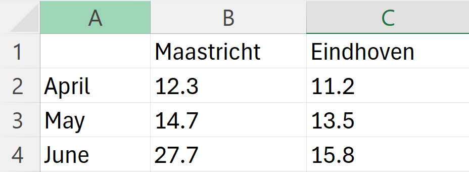

3. Get the data for April and May by - including only the first and second row - excluding the third row - using the names